# Different evidence of paper demand

Michael Falk

March 18-19, 2019

# 1 Introduction

The STN database records several types of ‘transaction’, which have a bearing on the STN’s demand for paper. In previous analyses, I have focussed on particular ‘out’ transactions (broadly speaking, sales). By seeing how many books the STN were selling, I tried to give a sense of how many sheets of paper they were using. It turns out, however, that there are two kinds of ‘in’ transaction in the database, of particular relevance to our research: ‘in (printing)’ and ‘in (assumed printing)’ transactions record print runs; ‘Bilan’ and ‘stock take’ transactions record stock sitting in the STN’s warehouse at particular points in time

By comparing these three, independent lines of data, hopefully we can get a clearer idea of how much paper the STN was bringing in, how much they were using, and how much they were wasting.

```r
# Connect to the database and load functions and packages
source('init.R')

# Import key data
orders <- fetch_table(stn, "orders") # Each transaction is part of an overarching 'order'
editions <- fetch_table(stn, "books") %>%
  # Estimate the sheets using the 'edition' and 'pages' info
  mutate(
    book_sheets = str_remove(book_sheets, "\\D") %>% as.numeric(),
    total_pages = sum_pages(pages),
    leaves = str_replace(edition, "[Ff]olio", "2") %>% str_remove("\\D") %>% as.numeric(),
    sheets_estimate = calculate_sheets(total_pages, leaves)
  ) # Each transaction concerns a particular edition
transactions <- fetch_table(stn, "transactions") %>% # Load transaction data
  left_join(orders, by = "order_code") %>% # Join to order information (e.g. to get dates)
  left_join(editions, by = "book_code") # Joine to edition information (e.g. to get format details)
```

# 2 The big picture: kinds of transaction

We do not know how comprehensive the data is, or how these different pieces fit together. The simplest thing to do is to see how many volumes are recorded for each book in each category of transaction, and see if the books balance.

The basic accounting unit in the database is ‘volumes exchanged’. So to begin, let’s see how many volumes were exchanged for each unique transaction type:

```r
transactions %>%
  group_by(direction_of_transaction) %>%
  summarise(
    volumes_exchanged = sum(total_number_of_volumes, na.rm = T),
    na_transactions = sum(is.na(total_number_of_volumes))
  ) %>%
  kable() %>%
  kable_styling(full_width = F, fixed_thead = T) %>%
  scroll_box(height = '300px')
```

| direction_of_transaction | volumes_exchanged | na_transactions |
| --- | --- | --- |
| Bilan | 440129 | 0 |
| Bilan (adjustment) | 215 | 0 |
| Bilan de sortie | 40132 | 0 |
| Catalogue | 10 | 0 |
| Commission | 786 | 0 |
| In | 318644 | 0 |
| In (assumed printing) | 228203 | 0 |
| In (Durand commission) | 12069 | 0 |
| In (found) | 469 | 0 |
| In (other) | 7243 | 0 |
| In (printing) | 251238 | 0 |
| In (profit and loss) | 2 | 0 |
| In (recount) | 1439 | 0 |
| In (rétiré) | 8322 | 0 |
| In (return) | 12360 | 0 |
| In (transfer) | 5781 | 0 |
| Out | -807224 | 3 |
| Out (binders) | -411 | 0 |
| Out (Durand commission) | -45451 | 0 |
| Out (faults) | -864 | 0 |
| Out (free gifts) | -2624 | 0 |
| Out (inferred) | -500 | 0 |
| Out (lost) | -6 | 0 |
| Out (missing) | -181 | 0 |
| Out (other) | -4676 | 0 |
| Out (profit and loss) | -826 | 0 |
| Out (return) | -1340 | 0 |
| out (transfer) | -14 | 0 |
| Out (transfer) | -5283 | 0 |
| Returned before arrival | 1472 | 0 |
| sales MS1003 | 683 | 0 |
| Sales MS1003 | 44027 | 0 |
| stock take | 6533 | 0 |
| Stock take | 199565 | 0 |

There are many types of transaction, and it is not clear from the FBTEE documentation what they all represent. Let us just focus on the ones specifically labelled ‘In’ and ‘Out’, and see how the totals compare.

```r
transactions %>%
  mutate(direction_of_transaction = str_to_lower(direction_of_transaction)) %>%
  filter(str_detect(direction_of_transaction, "^in|^out")) %>%
  mutate(
    direction = !str_detect(direction_of_transaction, "^in"),
    direction = map_chr(direction, function(x) {if (x) {return("Out")} else {return("In")}})
    ) %>%
  group_by(direction) %>%
  summarise(vols_exchanged = sum(total_number_of_volumes, na.rm = T)) %>%
  kable() %>%
  kable_styling(full_width = F)
```

| direction | vols_exchanged |
| --- | --- |
| In | 845770 |
| Out | -869400 |

The account doesn’t quite balance. How does it look if we examine only the STN editions?

```r
transactions %>%
  mutate(direction_of_transaction = str_to_lower(direction_of_transaction)) %>%
  filter(
    str_detect(direction_of_transaction, "^in|^out"), # Only ins and outs
    str_detect(edition_type, "(?<=^|\\s)STN") # only STN editions
    ) %>%
  mutate(
    direction = !str_detect(direction_of_transaction, "^in"),
    direction = map_chr(direction, function(x) {if (x) {return("Out")} else {return("In")}})
    ) %>%
  group_by(direction) %>%
  summarise(vols_exchanged = sum(total_number_of_volumes, na.rm = T)) %>%
  kable() %>%
  kable_styling(full_width = F)
```

| direction | vols_exchanged |
| --- | --- |
| In | 539319 |
| Out | -598965 |

What about these stocktakes? How are we to account for them? Probably the best way to look at them is to chart them over time, so we can see the warehoused stock rise and fall, and get a sense of how the stocktakes fit in with the rest of the data.

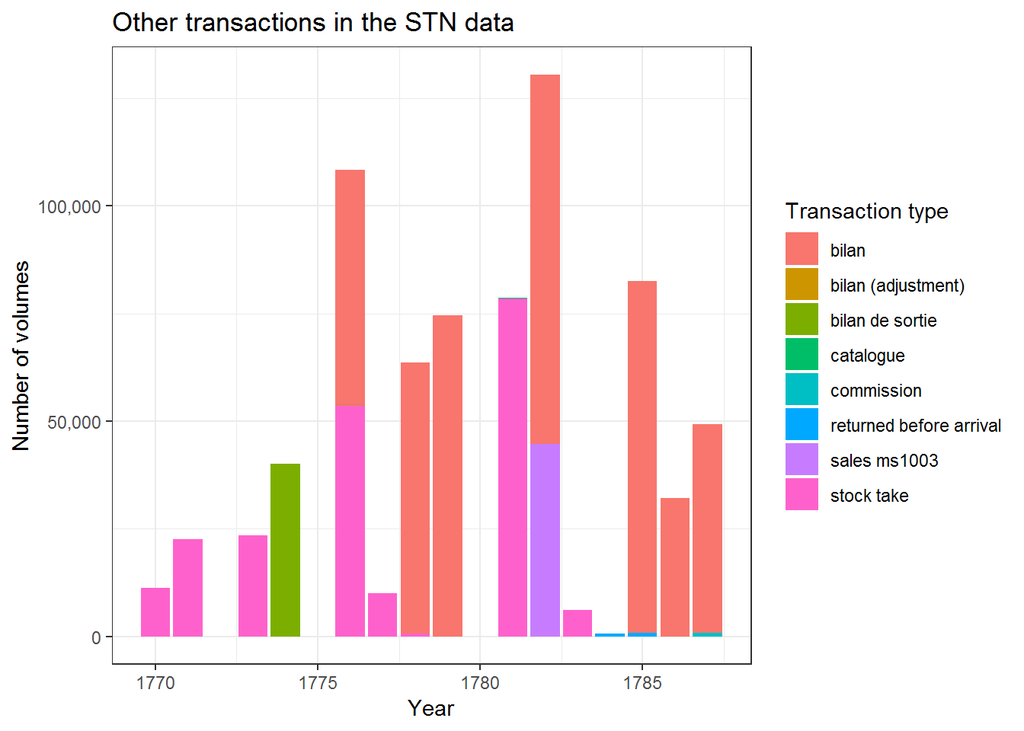

```r
transactions %>%
  mutate(direction_of_transaction = str_to_lower(direction_of_transaction)) %>%
  # exclude all 'in' and 'out' transactions
  filter(!str_detect(direction_of_transaction, "^in|^out")) %>%
  mutate(year = lubridate::ymd(date) %>% lubridate::year()) %>%
  ggplot(aes(x = year, y = total_number_of_volumes, fill = direction_of_transaction)) +
  geom_col() +
  scale_y_continuous(labels = scales::comma_format()) +
  labs(
    title = 'Other transactions in the STN data',
    x = 'Year',
    y = 'Number of volumes',
    fill = 'Transaction type'
  ) +
  theme_bw()
```

What is ‘sales ms1003?’ It is not clear why they have been coded differently to other ‘out’ transactions. MS1003 was a different kind of document, and SB thinks it may have been coded to allow comparison with the conventionally recorded sales. One thing to check is whether any of the MS1003 sales double up on other ‘out’ transactions.

```r
transactions %>%
  # Floor to the nearest month
  mutate(year_month = lubridate::ymd(date) %>% lubridate::floor_date(unit = "month")) %>%
  group_by(super_book_code.x, year_month) %>%
  filter(
    any(direction_of_transaction == "sales MS1003"),
    any(str_detect(direction_of_transaction, "^[Oo]ut"))
    ) %>%
  ungroup() %>%
  select(transaction_code, date, book_code, stn_abbreviated_title, total_number_of_volumes, client_code) %>%
  kable() %>%
  kable_styling()
```

| transaction_code | date | book_code | stn_abbreviated_title | total_number_of_volumes | client_code |
| --- | --- | --- | --- | --- | --- |
| tr0000011 | 17820520 | bk0002056 | Fanny Spingler | -4 | cl0839 |
| tr0000013 | 17820523 | bk0002056 | Fanny Spingler | -10 | cl1290 |
| tr0000031 | 17820518 | bk0002056 | Fanny Spingler | -8 | cl2120 |
| tr0000067 | 17820501 | bk0002056 | Fanny Spingler | 666 | NA |

The above script calls up all the `super_books` that have at least one ‘out’ transaction and one ‘ms1003 sale’ in the same month. As you can see, there is only 1 such `super_book` in the whole database, and it is pretty clear that the ‘ms1003 sale’ is not simply a duplicate of any of the other three. We could also just check by day…

```r
transactions %>%
  group_by(date) %>%
  filter(
    any(direction_of_transaction == "sale MS1003"),
    any(str_detect(direction_of_transaction, "^[Oo]ut"))
  ) %>%
  nrow() %>%
  paste0(., " rows returned!") %>%
  print()
```

```
## [1] "0 rows returned!"
```

# 3 Checking our sheets estimates against the manually entered `book_sheets` data

In discussion of our previous analysis, SB has asked whether we can check the accuracy of our sheets estimates against the manually-entered data. The STN often used sheets of paper as their accounting unit. The manually entered data, where it is drawn directly from the STN’s books, will therefore give a ground-truth value against which our estimates can be compared.

The sheets were estimated above, when the data was imported.

There are many NA values:

```r
editions %>%
  mutate(na = is.na(sheets_estimate) | is.na(book_sheets)) %>%
  group_by(na) %>%
  summarise(n = n()) %>%
  kable() %>%
  kable_styling(full_width = F)
```

| na | n |
| --- | --- |
| FALSE | 265 |
| TRUE | 3722 |

In other words, there are only 265 cases where we can directly compare the estimated sheets to the manually entered value.

The first question is how well our `sum_pages()` function is working to estimate the number of pages. We can have a look by comparing it to the `pages` and `quick_pages` columns of the `editions` table. The `quick_pages` column *does not* count blank pages, so we should expect our `total_pages` to differ by 1-3 pages from the `quick_pages`. Let’s just look at rows where there is a greater difference than 3:

```r
editions %>%
  mutate(diff = total_pages - as.numeric(quick_pages)) %>%
  filter(abs(diff) > 3) %>%
  arrange(desc(abs(diff))) %>%
  select(book_code, pages, quick_pages, total_pages) %>%
  kable() %>%
  kable_styling() %>%
  column_spec(2, width = "25%") %>%
  scroll_box(height = '400px')
```

| book_code | pages | quick_pages | total_pages |
| --- | --- | --- | --- |
| bk0001961 | [4], XXXVIII, 323, [1 bl.]; [2], 336; [4], [9]-328; [4], 329, [1 bl.]; [2], 462; [4], 409, [3 bl.]; [4], 396; [2], 381, [1 bl.]; [4], 362, [4 bl.]; [2], 389, [3 bl.] | 6746 | 3790 |
| bk0001494 | [24], 404 | 228 | 428 |
| bk0000662 | CLI, 455 p, XII, 406 | 924 | 1024 |
| bk0001455 | xvi, 347; x, 382 | 855 | 755 |
| bk0002597 | XLVIII, 394, [2, 2 f.]; [4], 400 | 950 | 850 |
| bk0002705 | [4], 337, [1] | 442 | 342 |
| bk0003143 | LIX, 404 | 563 | 463 |
| bk0003152 | XL, 590, XXVII | 557 | 657 |
| bk0002295 | XXXII, 269 | 391 | 301 |
| bk0004237 | [13]-XLIV-522; [5]-566-[4]; [5]-710; [5]-560-[1] | 2391 | 2435 |
| bk0005260 | XLVIII, 288 | 296 | 336 |
| bk0002470 | 515, [1 bl.]; [4], 570, [2 bl.]; [4], 426, [2 bl.]; [4], 483, [1 bl.]; [4], 400; [2], 446; [4], 429, [1 bl.] | 3331 | 3298 |
| bk0002120 | xxiv, 392; [1], 422; [4], 440 | 1303 | 1283 |
| bk0001402 | XVI, [XVI], 220 | 236 | 252 |
| bk0001456 | XIV, 237 [i.e. 267] | 267 | 281 |
| bk0002529 | [2], 376; [2] 390, [2 bl.]; [2 bl.], [2], 363, [1 bl.]; [2 bl.], [2], 377, [3 bl.]; [2], 373, [1 bl.]; [2], 351, [1 bl.]; [2 bl.], [2], 364; [2], 369, [5]; 378 | 3362 | 3376 |
| bk0000869 | [4]-159; [4]-123; [4]-124; [4]-142 | 548 | 536 |
| bk0002291 | [2], VIII, 99, [1 bl.]; [2], XII, 330; [2], 335, [1 bl.]; [2], 221, [1 bl.] | 1004 | 1016 |
| bk0002121 | [4], [I]-IV, [5]-315, [1 bl.]; 314, [2 bl.]; [2], 324; 275, [1 bl.], XXXII; [I]-XII, [13]-228, I-XXXII; 335, [1 bl.], XXIII, [1 bl.]; 335, [1 bl.]; 327, [1 bl.]; 300 | 2843 | 2854 |
| bk0000340 | XX, [4], 191 | 205 | 215 |
| bk0001134 | [20], 549, [1] | 560 | 570 |
| bk0001219 | CXXIV, 237 | 351 | 361 |
| bk0001496 | 96, 136, 31, 86; 61, 154 | 554 | 564 |
| bk0002057 | XXIV, 320 | 354 | 344 |
| bk0002297 | VIII, 232 | 230 | 240 |
| bk0003006 | 551; 480; 530 | 1551 | 1561 |
| bk0002100 | XIX, [1 bl.], 523, [1]; 490, [1], [5 bl.], 15, [1 bl.] | 1049 | 1056 |
| bk0002341 | [4]-108 | 112 | 105 |
| bk0002429 | 57, [7 bl.] | 57 | 64 |
| bk0000117 | XVI, 125, [3 bl.]; 147, [1, 2 bl.] | 288 | 294 |
| bk0001922 | [1]-4, [1-2], 5-418, [2 bl.]; 387, [1 bl.]; 287, [1] | 1092 | 1098 |
| bk0002012 | 201, [1 bl.], 123, [5 bl.], 112, 156 | 592 | 598 |
| bk0004370 | [4]-216; [4]-170, [7] | 393 | 387 |
| bk0000167 | [4 bl.], XI, [1], 350, [9, 1 bl.] | 371 | 376 |
| bk0000189 | XXIV, [5]-438; [2], [445]-876 | 897 | 892 |
| bk0000573 | LVI, 221 | 282 | 277 |
| bk0000638 | [2 bl], 71; [1 bl], 82; [1 bl], 52, [1 bl] | 205 | 210 |
| bk0001375 | xiii, [3], 285, [3]; 257, [5] | 561 | 566 |
| bk0001990 | 15, [1 bl.], 321, [2], [1 bl.]; 343, [1 bl.] | 679 | 684 |
| bk0002084 | 404; 443, [1 bl.]; 204, [4 bl.] | 1051 | 1056 |
| bk0002200 | [1 bl., 9], 54, [2 bl.], 104, [4] | 169 | 174 |
| bk0002251 | 30, 394; [2], 462; [2], 463, [1 bl.]; [2], 476; [2 bl.], [2], 484; [2], 596 | 2913 | 2918 |
| bk0002455 | 204, [4]; 187, [5 bl.] | 395 | 400 |
| bk0002815 | xxiii, [1], 287, [6], 290-572 | 595 | 600 |
| bk0000383 | [2], X, 300, 1, 3 bl.; [4], 302, 1, 1 bl. | 620 | 624 |
| bk0002104 | [4], LX, 452, [4 bl.]; [2], 490; [4], 640 | 1652 | 1656 |
| bk0002221 | 269, [3 bl.]; 255, [1 bl.] | 524 | 528 |
| bk0002365 | XXIII, [1 bl.], 221, [3 bl.] | 244 | 248 |
| bk0002533 | XII, 116, [4 bl.] | 128 | 132 |
| bk0002613 | XIV, 397, [3 bl.]; [4], 500, [3], [1 bl.] | 918 | 922 |
| bk0002666 | [2], XL, 461, [1 bl.]; [2], 432; [2], 428; [2], 388; [2], 368; 317, [3 bl.] | 2444 | 2448 |
| bk0002669 | [2], 344, [3]; [2], 364, [3]; VIII, 431, [1 bl.]; [2], 128 [i.e. 434]; [2], 333, [3 bl.] | 1928 | 1932 |
| bk0002854 | 368, [6]; 437, [1 bl.], [2]; 311, [1 bl.]; 315, [3], [2 bl.] | 1442 | 1446 |
| bk0002881 | [12], 272, [1, 3 bl.] | 284 | 288 |
| bk0003565 | XXXVI, 348; ([2 bl.], [1], [1 bl.], 363, [1 bl.] | 748 | 752 |
| bk0004221 | [4], 206, [2 bl]; [4], 121, [1, 2 bl.] | 336 | 340 |
| bk0005083 | xxiv, 487; [3, 1 bl.]-226 [i. e. 530], [2] | 1043 | 1047 |

Of these 57 cases where `quick_pages` and `total_pages` differ by more than 3, in nearly all the `total_pages` estimate seems to be better than the `quick_pages`. There are two main reasons:

1. The `quick_pages` estimate systematically ignores blank pages
2. The computer makes fewer arithmetical errors than the humans who entered the `quick_pages`

Now we can be confident that the `total_pages` estimate is solid, we can examine the `sheets_estimate`. As a quick reminder, the formula used to estimate the number of sheets is:
$$sheets = \lceil \frac{pages} {2 \times leaves} \rceil$$
where $leaves$ is the number of leaves each sheets is divided into (e.g. $2$ for a folio edition or $8$ for an octavo), and the $\lceil$ and $\rceil$ symbols indicate that we should round the result up to the nearest whole number, since any excess leaves from the sheet would generally have to be incorporated into the book as blank pages or otherwise wasted.

The table below shows all the books for which we have both a `sheets_estimate` calculated according to the formula, and a `book_sheets` value entered manually into the STN database.

```r
editions %>%
  filter(!is.na(sheets_estimate), !is.na(book_sheets)) %>%
  mutate(difference = sheets_estimate - book_sheets) %>%
  select(book_code, edition_type, full_book_title, pages, total_pages, edition, book_sheets, sheets_estimate) %>%
  kable() %>%
  kable_styling() %>%
  column_spec(3, width = "10em") %>%
  scroll_box(height = '400px')
```

| book_code | edition_type | full_book_title | pages | total_pages | edition | book_sheets | sheets_estimate |
| --- | --- | --- | --- | --- | --- | --- | --- |
| bk0000043 | Neuchâtel editions (non-STN) | Exposé des motifs qui ont engagé sa majesté le roi de Prusse à s’opposer au démembrement de la Bavière: juillet 1778 | 208, [1] | 209 | 8 | 20 | 14 |
| bk0000044 | Other Swiss editions | Exposé justificatif pour le peuple du canton de Fribourg en Suisse: au sujet des troubles arrivés en 1781 | [3], 54 | 57 | 8 | 8 | 4 |
| bk0000060 | Other Swiss editions | Essais, ou réflexions intéressantes relatives à la chymie, la médecine, l’économie et le commerce | 3, 233 | 236 | 8 | 155 | 15 |
| bk0000062 | French editions | Essais historiques et critiques sur les juifs anciens et modernes; ou Supplément aux Moeurs des Israélites de M. l’abbé Fleurs | XII, 216; IV, 252; IV, 124; VIII, 287, [1 bl.] | 908 | 12 | 38 | 38 |
| bk0000067 | Other Swiss editions | Esprit (l’) d’Addisson: ou Les beautés du Spectateur, du Babillard et du Gardien, consistant principalement dans une collection des feuilles de Mr. Addisson, avec un précis de sa vie, ouvrage nouvelle… | 276; 292; 283 | 851 | 8 | 545 | 54 |
| bk0000074 | French editions | Henri IV, drame lyrique en 3 actes et en prose, par M. de Rozoy [Versailles, les Comédiens italiens, 16 décembre 1774.] | IV, 78 | 82 | 8 | 5 | 6 |
| bk0000084 | Other Swiss editions | Abrégé de l’histoire poétique, ou Introduction à la mythologie par demandes et par réponses, à l’usage du College de Lausanne. Nouvelle édition revuë, corrigée et augmentée | 191, [1 bl.] | 192 | 8 | 12 | 12 |
| bk0000101 | STN editions | Sermons sur différens textes de l’Ecriture-Sainte, par J.E. Bertrand, membre de plusieurs académies, professeur de belles-lettres, et ci-devant ministre du Saint Evangile à Neuchâtel | 395, [1 bl.] | 396 | 8 | 25 | 25 |
| bk0000103 | Other Swiss editions | Journal d’un voyage de Constantinople en Pologne, fait à la suite de Son Excellence Mr Jaq. Porter, ambassadeur d’Angleterre, par le R. P. Joseph Boscowich… en 1762 | VIII, 323 | 331 | 12 | 14 | 14 |
| bk0000106 | Other Swiss editions | Maladies des enfants: traduit de l’anglois du docteur Jean Cooke | IV, 82, 1, 1 bl. | 88 | 8 | 6 | 6 |
| bk0000110 | Other Swiss editions | Questions de droit naturel et observations sur le traité du droit de la nature de M. le Baron de Wolf | XI, 439 | 450 | 8 | 19 | 29 |
| bk0000111 | Other Swiss editions | Voyages d’un philosophe, ou Observations sur les moeurs et les arts des peuples de l’Afrique, de l’Asie et de l’Amérique | 142 | 142 | 12 | 6 | 6 |
| bk0000119 | Other Swiss editions | Traité de l’homme selon les différentes merveilles qui le composent, par le P. André | XLVII, [1 bl.], 281; 245 | 574 | 8 | 355 | 36 |
| bk0000129 | Other Swiss editions | Discours de l’empereur Julien, contre les chrétiens, traduit par Mr. le marquis d’Argens …; Avec de nouvelles notes de divers auteurs | 175, [1] | 176 | 8 | 22 | 11 |
| bk0000132 | French editions | Ouvrages de feu Mr. Forbes, Lord-Président des Assises d’Edimbourg: contenants: des pensées sur la religion naturelle et révéleé, une lettre a un évêque; des reflexions sur l’incrédulité, traduits de … | xx, 461, [3] | 484 | 8 | 305 | 31 |
| bk0000136 | Other Swiss editions | Sermons sur différens textes de l’Ecriture Sainte [Rochemont] | VIII, 375 | 383 | 8 | 24 | 24 |
| bk0000137 | Other Swiss editions | Poesie del sig. Alberto Haller, tradotte in versi italiani dal sig. A. S. | XV, 174 | 189 | 16 | 24 | 6 |
| bk0000142 | French editions | Primatu (De) Romani Pontificis = Primauté (de la) du pape | xi, 513 | 524 | 8 | 33 | 33 |
| bk0000156 | British editions | Sermon prêché… sur la tombe de Pierre le Grand, le lendemain du jour que l’on reçut à St-Pétersbourg la nouvelle de la victoire navale remportée sur la flotte turque… par Platon | 15 | 15 | 12 | 1 | 1 |
| bk0000165 | Other Swiss editions | République (la) littéraire, ou Description allégorique et critique des sciences et des arts, ouvrage posthume de Dom Diego Saavedra Fajardo… traduit de l’espagnol, sur l’édition la plus correcte, publ… | XXIV, 162 | 186 | 12 | 7 | 8 |
| bk0000167 | Other Swiss editions | Observations sur des matières de jurisprudence criminelle | [4 bl.], XI, [1], 350, [9, 1 bl.] | 376 | 8 | 185 | 24 |
| bk0000179 | Other Swiss editions | Considérations sur les causes de la grandeur des Romains et de leur décadence | [4], 416 | 420 | 12 | 175 | 18 |
| bk0000185 | Other Swiss editions | Examen de la nouvelle histoire de Henri IV, de M. de Bury | [2], 99, [1] | 102 | 8 | 6 | 7 |
| bk0000189 | Swiss-International editions | Annales politiques de feu monsieur Charles Irénée Castel, abbé de St. Pierre, de l’Académie françoise | XXIV, [5]-438; [2], [445]-876 | 892 | 12 | 37 | 38 |
| bk0000193 | Other Swiss editions | Réflexions sur l’économie politique, ouvrage traduit de l’italien | XLIV, 359 | 403 | 12 | 17 | 17 |
| bk0000197 | Other Swiss editions | Médecine végétale, tirée uniquement des plantes usuelles, appliquées aux différentes maladies qui règnent dans les campagnes | VIII, 447 | 455 | 8 | 285 | 29 |
| bk0000198 | Other Swiss editions | Histoire du Parlement de Paris | XIV, 384 | 398 | 8 | 255 | 25 |
| bk0000200 | Other Swiss editions | Abrégé historique de la vie de Marie-Thérèse, impératrice-reine de Hongrie, tiré de la Galerie universelle des hommes célèbres etc. | 29, [3 bl.] | 32 | 8 | 2 | 2 |
| bk0000203 | Other Swiss editions | Conseils pour former une bibliothèque historique de la Suisse, par M. Haller | VI, 168 | 174 | 8 | 11 | 11 |
| bk0000205 | Other Swiss editions | Contes moraux et nouvelles idylles de D… et Sal. Gessner | [6], 230, [2 bl.] | 238 | 12 | 10 | 10 |

[output cut: 235 more lines]

There’s a problem, because the `book_sheets` column does not appear to record the sheets required to manufacture a single copy. There is no way, for example, that `bk0001477`, a book of 624 pages, required 5675 sheets to make a single copy. This must be the amount required for printing the whole edition. On the other hand, some of the books *do* simply record the sheets required for a single copy. For example, `bk0002338` has a `book_sheets` value of 26, which is identical to my calculated `sheets_estimate` of 26.

Can we take account of the print run data, and see if the `book_sheets` column makes sense then? If we divide the `book_sheets` by the number of copies printed, do we find the correct number of sheets for each copy?

**NB:** Since the unit of accounting is $volumes$ sold/printed etc., the formula is actually
$$sheets\_per\_copy = \frac{book\_sheets}{volumes \times volumes\_printed}$$
, where $volumes$ is the number of volumes in a multi-volume work, e.g. $3$ for a triple-decker novel like *Pride & Prejudice*.

```r
transactions %>%
  filter(str_detect(direction_of_transaction, "printing")) %>%
  group_by(book_code) %>%
  summarise(total_vols_moved = sum(total_number_of_volumes, na.rm = T)) %>%
  left_join(editions, by = "book_code") %>%
  mutate(
    sheets_per_copy = book_sheets / number_of_volumes / total_vols_moved
  ) %>%
  select(book_code, total_pages, book_sheets, sheets_estimate, sheets_per_copy) %>%
  drop_na() %>%
  kable() %>%
  kable_styling(full_width = F) %>%
  scroll_box(height = '400px')
```

| book_code | total_pages | book_sheets | sheets_estimate | sheets_per_copy |
| --- | --- | --- | --- | --- |
| bk0000101 | 396 | 25 | 25 | 0.0487329 |
| bk0000243 | 56 | 35 | 4 | 0.0233333 |
| bk0000654 | 40 | 5 | 3 | 0.0819672 |
| bk0000875 | 118 | 10 | 8 | 0.0099701 |
| bk0001092 | 550 | 35 | 35 | 0.0110759 |
| bk0001442 | 1782 | 75 | 75 | 0.0111342 |
| bk0001902 | 166 | 7 | 7 | 0.0053846 |
| bk0001906 | 253 | 16 | 16 | 0.0154889 |
| bk0001922 | 1098 | 46 | 46 | 0.0034535 |
| bk0001937 | 102 | 65 | 7 | 0.1287129 |
| bk0001957 | 132 | 9 | 9 | 0.0096670 |
| bk0001966 | 430 | 52 | 27 | 0.0035773 |
| bk0001970 | 44 | 275 | 3 | 0.5339806 |
| bk0001971 | 80 | 5 | 5 | 0.0046948 |
| bk0001973 | 136 | 9 | 9 | 0.0078740 |
| bk0001992 | 133 | 9 | 9 | 0.0090000 |
| bk0002007 | 936 | 39 | 39 | 0.0119339 |
| bk0002012 | 598 | 25 | 25 | 0.0320924 |
| bk0002017 | 20 | 3 | 3 | 0.0014713 |
| bk0002024 | 594 | 25 | 25 | 0.0014995 |
| bk0002057 | 344 | 215 | 22 | 0.2788586 |
| bk0002092 | 196 | 23 | 13 | 0.0076667 |
| bk0002101 | 840 | 105 | 105 | 0.0261715 |
| bk0002117 | 222 | 14 | 14 | 0.0325581 |
| bk0002119 | 1330 | 59 | 56 | 0.0065556 |
| bk0002120 | 1283 | 54 | 54 | 0.0060000 |
| bk0002121 | 2854 | 1785 | 179 | 0.0212099 |
| bk0002123 | 177 | 155 | 12 | 0.1977041 |
| bk0002129 | 52 | 4 | 4 | 0.0080000 |
| bk0002159 | 176 | 11 | 11 | 0.0105465 |
| bk0002161 | 158 | 10 | 10 | 0.0128205 |
| bk0002212 | 364 | 15 | 16 | 0.0144928 |
| bk0002221 | 528 | 33 | 33 | 0.0053502 |
| bk0002229 | 396 | 17 | 17 | 0.0226667 |
| bk0002251 | 2918 | 180 | 183 | 0.0053937 |
| bk0002283 | 52 | 35 | 4 | 0.0336538 |
| bk0002297 | 240 | 18 | 15 | 0.0149007 |
| bk0002302 | 52 | 325 | 4 | 0.6322957 |
| bk0002305 | 580 | 36 | 37 | 0.0094937 |
| bk0002314 | 119 | 5 | 5 | 0.0064350 |
| bk0002338 | 412 | 26 | 26 | 0.0082174 |
| bk0002339 | 294 | 185 | 19 | 0.1859296 |
| bk0002340 | 1188 | 29 | 50 | 0.0031083 |
| bk0002364 | 168 | 21 | 21 | 0.0279255 |
| bk0002365 | 248 | 155 | 16 | 0.1546906 |
| bk0002369 | 1565 | 98 | 98 | 0.0142712 |
| bk0002376 | 350 | 18 | 22 | 0.0045000 |
| bk0002417 | 552 | 35 | 35 | 0.0038717 |
| bk0002418 | 152 | 95 | 10 | 0.0915222 |
| bk0002425 | 2310 | 199 | 145 | 0.0040012 |
| bk0002434 | 299 | 20 | 19 | 0.0200000 |
| bk0002437 | 120 | 75 | 8 | 0.1530612 |
| bk0002439 | 580 | 180 | 73 | 0.1715920 |
| bk0002441 | 1844 | 78 | 77 | 0.0097500 |
| bk0002455 | 400 | 165 | 17 | 0.0403620 |
| bk0002457 | 568 | 36 | 36 | 0.0188679 |
| bk0002505 | 44 | 2 | 3 | 0.0026667 |
| bk0002519 | 328 | 30 | 21 | 0.0100000 |
| bk0002529 | 3376 | 212 | 211 | 0.0010469 |
| bk0002551 | 80 | 5 | 5 | 0.0050000 |
| bk0002553 | 576 | 36 | 36 | 0.0133136 |
| bk0002583 | 80 | 5 | 5 | 0.0048828 |
| bk0002613 | 922 | 80 | 58 | 0.0200000 |
| bk0002658 | 670 | 28 | 28 | 0.0067114 |
| bk0002665 | 414 | 27 | 26 | 0.0066634 |
| bk0002666 | 2448 | 155 | 306 | 0.0028196 |
| bk0002678 | 584 | 385 | 37 | 0.0538311 |
| bk0002683 | 2840 | 119 | 119 | 0.0042597 |
| bk0003043 | 3442 | 215 | 216 | 0.0053276 |
| bk0003395 | 488 | 21 | 21 | 0.0201342 |
| bk0003398 | 208 | 13 | 13 | 0.0118182 |
| bk0003618 | 1543 | 96 | 97 | 0.0106667 |
| bk0003702 | 6515 | 360 | 408 | 0.0033333 |
| bk0003719 | 4 | 1 | 1 | 0.0009025 |
| bk0003721 | 55 | 10 | 7 | 0.0049432 |

None of these numbers match up. If the `book_sheets` described the number of sheets needed to produce a whole edition, then we would expect the `sheets_per_copy` to be roughly equal to `sheets_estimate`. Instead, they are all nonesense figures less than 1.

```r
transactions %>%
  filter(!str_detect(direction_of_transaction, regex("^out|^in", ignore_case = T))) %>%
  group_by(book_code) %>%
  summarise(total_vols_moved = sum(total_number_of_volumes, na.rm = T)) %>%
  left_join(editions, by = "book_code") %>%
  mutate(
    sheets_per_copy = book_sheets / number_of_volumes / total_vols_moved
  ) %>%
  select(book_code, total_pages, book_sheets, sheets_estimate, sheets_per_copy) %>%
  drop_na() %>%
  kable() %>%
  kable_styling(full_width = F) %>%
  scroll_box(height = '400px')
```

| book_code | total_pages | book_sheets | sheets_estimate | sheets_per_copy |
| --- | --- | --- | --- | --- |
| bk0000043 | 209 | 20 | 14 | 1.0000000 |
| bk0000060 | 236 | 155 | 15 | 31.0000000 |
| bk0000062 | 908 | 38 | 38 | 0.6440678 |
| bk0000067 | 851 | 545 | 54 | 60.5555556 |
| bk0000084 | 192 | 12 | 12 | 0.1071429 |
| bk0000101 | 396 | 25 | 25 | 0.0649351 |
| bk0000103 | 331 | 14 | 14 | 0.3589744 |
| bk0000106 | 88 | 6 | 6 | 0.3333333 |
| bk0000110 | 450 | 19 | 29 | 2.3750000 |
| bk0000111 | 142 | 6 | 6 | 0.8571429 |
| bk0000129 | 176 | 22 | 11 | 2.0000000 |
| bk0000132 | 484 | 305 | 31 | 14.5238095 |
| bk0000136 | 383 | 24 | 24 | 0.7741935 |
| bk0000137 | 189 | 24 | 6 | 12.0000000 |
| bk0000142 | 524 | 33 | 33 | 1.3200000 |
| bk0000156 | 15 | 1 | 1 | 0.5000000 |
| bk0000165 | 186 | 7 | 8 | 0.4666667 |
| bk0000167 | 376 | 185 | 24 | 26.4285714 |
| bk0000179 | 420 | 175 | 18 | 13.4615385 |
| bk0000189 | 892 | 37 | 38 | 1.5416667 |
| bk0000193 | 403 | 17 | 17 | 2.8333333 |
| bk0000198 | 398 | 255 | 25 | 4.3220339 |
| bk0000200 | 32 | 2 | 2 | 0.0363636 |
| bk0000203 | 174 | 11 | 11 | 1.2222222 |
| bk0000205 | 238 | 10 | 10 | 1.1111111 |
| bk0000225 | 510 | 35 | 32 | 0.5645161 |
| bk0000229 | 171 | 7 | 8 | 0.1346154 |
| bk0000233 | 32 | 3 | 2 | 0.1666667 |
| bk0000236 | 16 | 1 | 1 | 0.5000000 |
| bk0000243 | 56 | 35 | 4 | 0.3608247 |

[output cut: 206 more lines]

That produces many absurd and some non-absurd results. But it is still not quite clear what is going on.

How many of the STN editions do we now have some kind of estimate for?

```r
editions %>%
  filter(str_detect(edition_type, "(?<=^|\\s)STN")) %>%
  summarise(
    n = n(),
    with_manual_sheets = (!is.na(book_sheets)) %>% sum(),
    with_estimate = (!is.na(sheets_estimate)) %>% sum(),
    with_neither = (is.na(book_sheets) & is.na(sheets_estimate)) %>% sum(),
    only_manual = (!is.na(book_sheets) & is.na(sheets_estimate)) %>% sum()
  )%>%
  kable() %>%
  kable_styling(full_width = F)
```

| n | with_manual_sheets | with_estimate | with_neither | only_manual |
| --- | --- | --- | --- | --- |
| 247 | 95 | 186 | 45 | 16 |

Of these 16 books that have only a manually entered `book_sheets` value, how many are trustworthy?

```r
editions %>%
  filter(
    str_detect(edition_type, "(?<=^|\\s)STN"),
    !is.na(book_sheets),
    is.na(sheets_estimate)
  ) %>%
  select(book_code, full_book_title, quick_pages, total_pages, edition, book_sheets) %>%
  kable() %>%
  kable_styling(full_width = T) %>%
  scroll_box(height = '400px')
```

| book_code | full_book_title | quick_pages | total_pages | edition | book_sheets |
| --- | --- | --- | --- | --- | --- |
| bk0000091 | Jeu (le) des trois sept | NA | NA | 12 | 1 |
| bk0000094 | Introduction à la connaissance géographique et politique des Etats de l’Europe | NA | NA | 8 | 11 |
| bk0001292 | Maître de la langue allemande ou nouvelle Grammaire allemande… composée sur le modèle des meilleurs auteurs de nos jours et principalement sur celui de M. le Prof. Gottsched | NA | NA | NA | 35 |
| bk0001300 | Histoire des conquêtes de Gustave-Adolfe, roi de Suède, en Allemagne ou Campagnes de ce monarque en 1630, 1631, 1632, précédées d’une introduction contenant l’origine & le commencement de la guerre de… | NA | NA | NA | 27 |
| bk0001490 | Incas (les), ou la destruction de l’empire du Pérou | NA | NA | 12 | 29 |
| bk0001579 | [Abrégé de l’histoire sainte et du catéchisme] | NA | NA | NA | 6 |
| bk0001660 | Collection complète des oeuvres de Madame Riccoboni | NA | NA | 8 | 160 |
| bk0001932 | Apologie du marquis de Fogliani, ci-devant vice roi de Naples | NA | NA | 4 | 3 |
| bk0002266 | Histoire philosophique et politique des établissements et du commerce des Européens dans les deux Indes | NA | 3669 | NA | 360 |
| bk0002631 | Thévenon (le), ou Les journées de la montagne | 490 | 492 | NA | 205 |
| bk0002656 | Vie (la) de David Hume, écrite par lui-même | NA | NA | 12 | 2 |
| bk0002729 | Tableau de la monarchie française [discours préliminaire] | NA | NA | NA | 4 |
| bk0002742 | Dieu. Réponse de M. de Voltaire au systême de la nature | NA | NA | 8 | 2 |
| bk0002763 | Réflexions philosophiques sur le système de la nature | NA | NA | 8 | 43 |
| bk0003767 | Tableau de Paris | NA | NA | 8 | 52 |
| bk0003820 | [Réponse à M.Mallet sur Genève] | NA | NA | NA | 1 |

Initially I thought that the manually entered values would be more accurate, because they were derived directly from the STN’s books. Often they recorded stocks in sheets, so we could presume that the number of sheets recorded in their books would closely match the actual number of sheets they were buying and selling. But the `book_sheets` column seems to record many different kinds of data, sometimes recording the number of sheets required for a particular copy, and sometimes recording some other figure whose relationship to our transactions figures is unclear.

Therefore I conclude that we cannot rely on the `book_sheets` data, and should instead use our calculated `sheets_estimate` as the best guess we have of the actual number of sheets required for the editions in the records.

# 4 Comparing print runs, sales and stocktakes.

Following the above analysis, It seems that the print run data is almost there, and we can rely on our calculated sheet estimate more than the data hard-coded into the original STN database.

In a following report, I will go into more detail, but for now, let’s just quickly compare how the print run data compares to the sales data over time. Can we see the STN bringing in paper and offloading it?

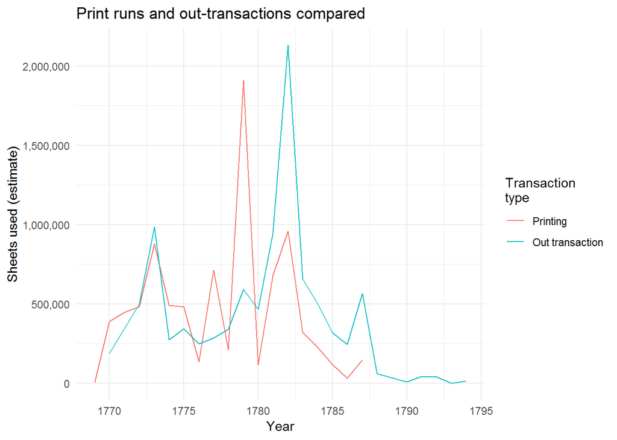

```r
stn_trans_sheets <- transactions %>%
  mutate(
    # Make all number positive
    total_number_of_volumes = abs(total_number_of_volumes),
    # Sort the 34 different transaction types into the three main ones
    transaction_type = case_when(
      # We are only interesting in print runs among the in transactions
      str_detect(direction_of_transaction, regex("printing", ignore_case = T)) ~ "in",
      str_detect(direction_of_transaction, regex("^in", ignore_case = T)) ~ "NA",
      str_detect(direction_of_transaction, regex("^out", ignore_case = T)) ~ "out",
      TRUE ~ "neutral"
    ),
    # Calculate how many sheets were used for each transaction
    sheets_used = total_number_of_volumes / number_of_volumes * sheets_estimate,
    # Infer year data
    year = lubridate::ymd(date) %>% lubridate::year()
    ) %>%
  # Just focus on editions the STN manufactured themselves
  filter(
    transaction_type %in% c("in","out"),
    edition_type %in% c('STN editions', 'Livres en Société: STN joint editions', 'Commissioned STN edition')
    )

stn_trans_sheets %>%
  # Sum up by year for each transaction type
  group_by(transaction_type, year) %>%
  summarise(sheets_used = sum(sheets_used, na.rm = T)) %>%
  drop_na() %>%
  ungroup() %>%
  ggplot(aes(x = year, y = sheets_used, colour = transaction_type)) +
  theme_minimal() +
  scale_colour_discrete(labels = c("in" = "Printing", "out" = "Out transaction")) +
  scale_y_continuous(labels = scales::comma_format()) +
  labs(
    title = "Print runs and out-transactions compared",
    colour = "Transaction\ntype",
    y = "Sheets used (estimate)",
    x = "Year"
  ) +
  geom_line()
```

The new graph does accord with what we might expect. In 1777 and 1779, there are peaks in the demand for paper for printing, followed in 1779 and 1782 with peaks in the sheets actually sold or otherwise sent out from the STN.

Let’s just focus on the big spike in 1779 printings, followed by the spike in 1782 sales. Are they for the same books? Can we see a three-year lag here between manufacture and sale?

```r
# Look first at 1779 printings
stn_trans_sheets %>%
  filter(transaction_type == "in", year == 1779) %>%
  group_by(book_code, stn_abbreviated_title) %>%
  summarise(sheets_used = sum(sheets_used, na.rm = T)) %>%
  arrange(desc(sheets_used)) %>%
  kable(caption = "1779 printings") %>%
  kable_styling(full_width = F) %>%
  scroll_box(height = '400px')
```

1779 printings

| book_code | stn_abbreviated_title | sheets_used |
| --- | --- | --- |
| bk0000994 | Bible | 1163151 |
| bk0002666 | Voyage au pôle austral et autour du monde | 467262 |
| bk0002119 | Elémens de l’histoire d’Angleterre | 56000 |
| bk0002120 | Elémens de l’histoire de France | 54000 |
| bk0002590 | sermons de Bertrand | 50128 |
| bk0002441 | Nouvel abeilard | 38500 |
| bk0001442 | Histoire de gil blas de Santillane | 31575 |
| bk0002297 | Jammabos (les) | 18120 |
| bk0002084 | Discours d’Albon | 16500 |
| bk0002161 | Essai sur la colonie de Sainte-Lucie | 7800 |
| bk0002563 | Relation des derniers jours de M. J. J. Rousseau | 2985 |
| bk0002377 | Manière de faire le pain | 2000 |
| bk0002641 | Traité de Paix | 1800 |
| bk0000091 | Jeux des 3 Sept | 0 |
| bk0000094 | Introduction à la géographie | 0 |
| bk0001988 | son cathécumême | 0 |
| bk0002074 | Dictionnaire de chimie | 0 |

```r
# Then at the 1882 sales
stn_trans_sheets %>%
  filter(transaction_type == "out", year == 1782) %>%
  group_by(book_code, stn_abbreviated_title) %>%
  summarise(sheets_used = sum(sheets_used, na.rm = T)) %>%
  arrange(desc(sheets_used)) %>%
  kable(caption = "1882 sales and other transfers") %>%
  kable_styling(full_width = F) %>%
  scroll_box(height = '400px')
```

1882 sales and other transfers

| book_code | stn_abbreviated_title | sheets_used |
| --- | --- | --- |
| bk0002616 | Tableau de Paris | 798486.000 |
| bk0002666 | Voyage de Cook | 266220.000 |
| bk0001961 | Bibliotheque | 142105.200 |
| bk0002066 | reduction de Paris | 120704.000 |
| bk0002033 | Contrat conjugal | 86961.000 |
| bk0002021 | Confessions (les) de J.J. Rousseau, suivie des réveries du prommeneur solitaire | 79200.000 |
| bk0000994 | Bible | 56947.000 |
| bk0003702 | Bomare | 50592.000 |
| bk0002066 | Reduction de Paris | 40848.000 |
| bk0002654 | Vérite (de la) | 39600.000 |
| bk0002511 | Confrontation | 37840.000 |
| bk0002122 | Elémens de Milliot | 32772.444 |
| bk0002281 | Inceste avoué | 27314.000 |
| bk0003770 | Correspondance de Rillet | 24171.000 |
| bk0002195 | Campagnes du Compte d’Estaing | 18000.000 |
| bk0002021 | Confessions de Rousseau | 17952.000 |
| bk0001906 | Adelaïde ou Mémoires de la marq de M. | 16432.000 |
| bk0002290 | Interprète de la nature | 15540.000 |
| bk0002470 | Oeuvres de Piron | 14076.000 |
| bk0002362 | Liaisions dangereuses | 11730.000 |
| bk0003770 | Correspondance | 11634.000 |
| bk0002418 | Mizrim | 10300.000 |
| bk0003496 | Théatre de société | 10285.000 |
| bk0002689 | Zoe | 10080.000 |
| bk0002362 | liaisions dangereuses | 9522.000 |
| bk0002680 | Voyage en suisse | 9384.000 |
| bk0002281 | Inceste | 9002.000 |
| bk0002214 | Habitant de Guadeloupe | 8932.000 |
| bk0002120 | Elémens de l’histoire de France | 7506.000 |
| bk0002006 | Oeuvres de Dorat | 6832.778 |

[output cut: 194 more lines]

At first glance, there does not appear to be a strong relationship between the 1779 peak in printing, and the 1882 peak in sales. This may repay further investigation, however.